# COURSERA - Reproducible Research

Bruce Granger

May 5, 2016

BACKGROUND: This analysis makes use of data from a personal activity monitoring device. The data is taken at 5 minute intervals through out the day. The data consists of two months of data from an anonymous individual collected during the months of October and November, 2012 and includes the number of steps taken in 5 minute intervals each day.

SECONDARY OBJECTIVES:

- Explain code blocks

[Personal Activity Monitoring Dataset](https://d396qusza40orc.cloudfront.net/repdata%2Fdata%2Factivity.zip) [52K]

- Steps: Number of steps taking in a 5-minute interval (missing values are coded as NA)
- Date: The date on which the measurement was taken in YYYY-MM-DD format
- Interval: Identifier for the 5-minute interval in which measurement was taken
- The dataset is stored in a comma-separated-value (CSV) file and there are a total of 17,568 observations in this dataset.

#### ——————————————— SETUP ——————————————————————————

1. In the setup block, obtaining the current working directory, which will be changed during this routine then returned to the original working directory.
2. Path variables hold path information.
3. Zip variables hold name of the Zip file and the file within the zip containing the activity monitoring dataset.

```r
ORG_WD<-getwd()
R_Path<-("L:/Coursera/DataScience/Reproducible_Research/Reproducible-ResearchAssignmentW2")
Raw_Data_Path<-("L:/Coursera/DataScience/Reproducible_Research")
Zip_Name<-("repdata_data_activity.zip")
Zip_File_Name<-("activity.csv")
setwd(Raw_Data_Path)
```

#### ——————————————— FILE READING ———————————————————————–

```r
# DETERMINE IF FILE (ACTIVITY) HAS BEEN UNZIPED, IF NO THEN UNZIP ELSE DO NOTHING.
if(file.exists(Zip_File_Name)){
        print("FILE EXISTS, NOTHING TO DO")#CONDITION TRUE - DO NOTHING.
}else{unzip(paste(Raw_Data_Path,"/",Zip_Name, sep = ""))     #CONDITION FALSE - UNZIP FILE
}
```

```
## [1] "FILE EXISTS, NOTHING TO DO"
```

```r
# READ (ACTIVITY MONITORING DATASET) FILE INTO MEMORY, EXPLICITLY DEFINE COLUMN CLASS.
Act<- read.csv(paste(Raw_Data_Path,"/",Zip_File_Name, sep = ""), header=TRUE, sep=",",
               colClasses=c("numeric", "character", "numeric"))
str(Act)   # NOTICE THE DATE FIELD IS DEFINE OF CHARACTER TYPE (chr), THIS WILL BE USED WHEN CONVERTED TO DATE USING as.DATE
```

```
## 'data.frame':    17568 obs. of  3 variables:
##  $ steps   : num  NA NA NA NA NA NA NA NA NA NA ...
##  $ date    : chr  "2012-10-01" "2012-10-01" "2012-10-01" "2012-10-01" ...
##  $ interval: num  0 5 10 15 20 25 30 35 40 45 ...
```

```r
# NOTICE THAT ALL 17,568 OBSERVATIONS AND THREE VARIABLES (steps, date, & interval) WERE READ INTO MEMORY.
```

#### ——————————————— DATA MANUPLIATION - STEPS PER DAY ————————————————

```r
# REMOVE NA VALUES FROM DATA FRAME.
library(stats)
Act_1<-na.omit(Act)
# NOTICE THE OBSERVATIONS NOW TOTAL 15,264, WHICH MEANS 2,304 HAD "N/A".
str(Act_1)
```

```
## 'data.frame':    15264 obs. of  3 variables:
##  $ steps   : num  0 0 0 0 0 0 0 0 0 0 ...
##  $ date    : chr  "2012-10-02" "2012-10-02" "2012-10-02" "2012-10-02" ...
##  $ interval: num  0 5 10 15 20 25 30 35 40 45 ...
##  - attr(*, "na.action")=Class 'omit'  Named int [1:2304] 1 2 3 4 5 6 7 8 9 10 ...
##   .. ..- attr(*, "names")= chr [1:2304] "1" "2" "3" "4" ...
```

```r
# REMOVE ENTRIES THAT ARE 0 "ZERO".
Act_2<-Act_1[Act_1$steps!=0,]
# NOTICE THE OBSERVATIONS NOW TOTAL 4,250, WHICH 11,014 HAD "0" IN THE STEP FIELD.
str(Act_2)
```

```
## 'data.frame':    4250 obs. of  3 variables:
##  $ steps   : num  117 9 4 36 25 90 411 413 415 519 ...
##  $ date    : chr  "2012-10-02" "2012-10-02" "2012-10-03" "2012-10-03" ...
##  $ interval: num  2210 2215 410 430 535 ...
##  - attr(*, "na.action")=Class 'omit'  Named int [1:2304] 1 2 3 4 5 6 7 8 9 10 ...
##   .. ..- attr(*, "names")= chr [1:2304] "1" "2" "3" "4" ...
```

```r
# CONVERTING THE DATE FIELD, WHICH IS OF OBJECT TYPE.CHARACTER, TO A DATE OBJECT CLASS.
Act_2$date <- as.Date(Act_2$date, format = "%Y-%m-%d")
str(Act_2)
```

```
## 'data.frame':    4250 obs. of  3 variables:
##  $ steps   : num  117 9 4 36 25 90 411 413 415 519 ...
##  $ date    : Date, format: "2012-10-02" "2012-10-02" ...
##  $ interval: num  2210 2215 410 430 535 ...
##  - attr(*, "na.action")=Class 'omit'  Named int [1:2304] 1 2 3 4 5 6 7 8 9 10 ...
##   .. ..- attr(*, "names")= chr [1:2304] "1" "2" "3" "4" ...
```

```r
# COERCING THE INTERVAL FIELD FROM A NUMERIC CLASS INTO A FACTOR.
Act_2$interval<-as.factor(Act_2$interval)
str(Act_2)
```

```
## 'data.frame':    4250 obs. of  3 variables:
##  $ steps   : num  117 9 4 36 25 90 411 413 415 519 ...
##  $ date    : Date, format: "2012-10-02" "2012-10-02" ...
##  $ interval: Factor w/ 269 levels "0","5","10","15",..: 249 250 35 38 50 53 54 55 56 57 ...
##  - attr(*, "na.action")=Class 'omit'  Named int [1:2304] 1 2 3 4 5 6 7 8 9 10 ...
##   .. ..- attr(*, "names")= chr [1:2304] "1" "2" "3" "4" ...
```

```r
# REQUIREMENT 1: TOTAL NUMBER OF STEPS TAKEN EACH DAY.
# GROUP (AGGREGATE) THE TOTAL (SUM) STEPS TAKEN BY DATE.
SPD <- aggregate(steps ~ date, Act_2, sum)
colnames(SPD) <- c("Date","Total_Steps_Per_Day")
str(SPD)
```

```
## 'data.frame':    53 obs. of  2 variables:
##  $ Date               : Date, format: "2012-10-02" "2012-10-03" ...
##  $ Total_Steps_Per_Day: num  126 11352 12116 13294 15420 ...
```

```r
# STEPS TAKEN PER DAY
head(SPD)
```

```
##         Date Total_Steps_Per_Day
## 1 2012-10-02                 126
## 2 2012-10-03               11352
## 3 2012-10-04               12116
## 4 2012-10-05               13294
## 5 2012-10-06               15420
## 6 2012-10-07               11015
```

#### ——————————- PLOTTING STEPS PER DAY ————————————————————————–

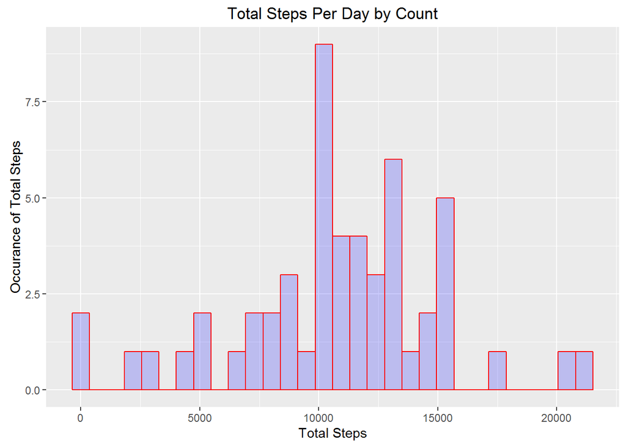

```r
# LOAD THE GGPLOT2 LIBRARY
library(ggplot2)
# REQUIREMENT 2: MAKE HISTOGRAM OF THE TOTAL NUMBER OF STEPS TAKEN EACH DAY.
qplot(x=Total_Steps_Per_Day, data=SPD, main="Total Steps Per Day by Count",
      geom="histogram",xlab = "Total Steps", fill=I("blue"),col=I("red"),
      ylab = "Occurance of Total Steps", alpha=I(.2), bins = 30)
```

#### ——————————- PLOTTING MEAN & MEDIAN STEPS PER DAY —————————————————–

```r
# REQUIREMENT 3: CALCULATE THE MEAN AND MEDIAN STEPS PER DAY.
SPD_Mean<-mean(SPD$Total_Steps_Per_Day)
SPD_Median<-median(SPD$Total_Steps_Per_Day)
sprintf("%.9f", SPD_Mean) # MEAN
```

```
## [1] "10766.188679245"
```

```r
sprintf("%.9f", SPD_Median)# MEDIAN
```

```
## [1] "10765.000000000"
```

#### ———————- DATA MANUPLIATION - AVG STEPS TAKEN, AVG ACROSS ALL DAYS ——————————–

```r
#  BEGINNING WITH ORIGINAL DATASET, Act (Activity Monitoring Dataset), WHICH CONTAINS "NA" AND ZERO (0) VALUES IN THE STEPS FIELD.
Act_3<-Act
str(Act_3)
```

```
## 'data.frame':    17568 obs. of  3 variables:
##  $ steps   : num  NA NA NA NA NA NA NA NA NA NA ...
##  $ date    : chr  "2012-10-01" "2012-10-01" "2012-10-01" "2012-10-01" ...
##  $ interval: num  0 5 10 15 20 25 30 35 40 45 ...
```

```r
#    COERCING THE DATE FIELD IN THE ACT_3 DATA.FRAME, WHICH IS OF OBJECT TYPE.CHARACTER(chr), TO A DATE OBJECT CLASS
#    WITH A FORMATE OF YEAR-MONTH-DAY.
Act_3$date <- as.Date(Act_3$date, format = "%Y-%m-%d")
str(Act_3)
```

```
## 'data.frame':    17568 obs. of  3 variables:
##  $ steps   : num  NA NA NA NA NA NA NA NA NA NA ...
##  $ date    : Date, format: "2012-10-01" "2012-10-01" ...
##  $ interval: num  0 5 10 15 20 25 30 35 40 45 ...
```

```r
# COERCING THE INTERVAL FIELD IN THE ACT_3 DATA.FRAME, FROM A NUMERIC (num) CLASS INTO A FACTOR.
Act_3$interval <- as.factor(Act_3$interval)
str(Act_3)
```

```
## 'data.frame':    17568 obs. of  3 variables:
##  $ steps   : num  NA NA NA NA NA NA NA NA NA NA ...
##  $ date    : Date, format: "2012-10-01" "2012-10-01" ...
##  $ interval: Factor w/ 288 levels "0","5","10","15",..: 1 2 3 4 5 6 7 8 9 10 ...
```

```r
# REQUIREMENT 4: TOTAL NUMBER OF STEPS TAKEN EACH DAY
# GROUP (AGGREGATE) THE MEAN STEPS TAKEN BY INTERVAL, REMOVING THE NA VALUES (na.rm=TRUE) FROM THE DATASET.
# INTO A DATA.FRAME CALLED MSPI (MEAN STEPS PER INTERVAL)
MSPI <- aggregate(Act_3$steps, by = list(interval = Act_3$interval),FUN=mean, na.rm=TRUE)
str(MSPI)
```

```
## 'data.frame':    288 obs. of  2 variables:
##  $ interval: Factor w/ 288 levels "0","5","10","15",..: 1 2 3 4 5 6 7 8 9 10 ...
##  $ x       : num  1.717 0.3396 0.1321 0.1509 0.0755 ...
```

```r
# COERCING THE INTERVAL FIELD IN THE MSPI DATA.FRAME, FROM A FACTOR INTO A INTEGER (INT) CLASS.
MSPI$interval <-as.integer(levels(MSPI$interval)[MSPI$interval])
str(MSPI)
```

```
## 'data.frame':    288 obs. of  2 variables:
##  $ interval: int  0 5 10 15 20 25 30 35 40 45 ...
##  $ x       : num  1.717 0.3396 0.1321 0.1509 0.0755 ...
```

```r
# RENAMING THE COLUMNS, AS A RESULT OF THE AGGERGATE PROCESS, TO BETTER IDENTIFY THE FIELD.
colnames(MSPI) <- c("Interval", "MSPI")
str(MSPI)
```

```
## 'data.frame':    288 obs. of  2 variables:
##  $ Interval: int  0 5 10 15 20 25 30 35 40 45 ...
##  $ MSPI    : num  1.717 0.3396 0.1321 0.1509 0.0755 ...
```

#### ——————————- PLOTTING AVG STEPS TAKEN, AVG ACROSS ALL DAYS ———————————–

[figure not shown]

```r
ggplot(MSPI,aes(x=Interval, y=MSPI))+
        geom_line(color="red", size=.1) +
        theme(panel.background = element_rect(fill = 'grey95'),
        panel.grid.major = element_line(colour = "black", size=.1),
        panel.grid.minor = element_line(colour = "blue")) +
        labs(title="MEAN STEPS TAKEN PER INTERVAL", x="Time Interval (5 Sec)", y="MEAN Number of Steps")
```

#### —– WHICH 5-MIN INTERVAL, ON AVG ACROSS ALL DAYS, IS THE MAX NUMBERS OF STEPS ———–

```r
library(dplyr)
# REQUIREMENT 5: USING THE FILTER FUNCTION WITHIN THE DPLYR PACKAGE
# WITHIN THE MSPI DATA.FRAME, FIND THE MAX STEPS WITHING THE MSPI FIELD
print(filter(MSPI, MSPI == max(MSPI$MSPI)))
```

```
##   Interval     MSPI
## 1      835 206.1698
```

#### ————————- MEDIAN IN PLACE OF NA VALUES —————————————————————

```r
# REQUIREMENT 5: CALCULATE THE TOTAL NUMBER OF MISSING VALUES (NA) IN THE STEPS FIELD.
sum(is.na(Act_3$steps))
```

```
## [1] 2304
```

```r
# REQUIREMENT 6:  REPLACE MISSING VALUES (NA) mean/median
Act_4<-Act_3
Act_4$steps[which(is.na(Act_4$steps))]<-SPD_Median
# REQUIREMENT 7: CALCULATE THE MEAN AND MEDIAN STEPS PER DAY WITH MISSING VALUES (NA) REPLACED WITH MEDIAN.
Act_4$date <- as.Date(Act_4$date, format = "%Y-%m-%d")
Act_4$interval <- as.factor(Act_4$interval)
MSPI_NONA <- aggregate(Act_4$steps, by = list(interval = Act_4$interval),FUN=mean, na.rm=TRUE)
MSPI_NONA$interval <-as.integer(levels(MSPI_NONA$interval)[MSPI_NONA$interval])
colnames(MSPI_NONA) <- c("Interval", "MSPI")
SPD_Mean_NONA<-mean(MSPI_NONA$MSPI)
SPD_Median_NONA<-median(MSPI_NONA$MSPI)
# MEAN WITHOUT NA's
sprintf("%.9f", SPD_Mean)
```

```
## [1] "10766.188679245"
```

```r
# MEAN, MEDIAN IN PLACE OF NA VALUES
sprintf("%.9f", SPD_Mean_NONA)
```

```
## [1] "1444.283242259"
```

```r
# MEAN WITHOUT NA's - MEAN, MEDIAN IN PLACE OF NA VALUES
sprintf("%.9f", SPD_Mean-SPD_Mean_NONA)
```

```
## [1] "9321.905436987"
```

```r
# MEDIAN WITHOUT NA's
sprintf("%.9f", SPD_Median)
```

```
## [1] "10765.000000000"
```

```r
# MEDIAN, MEDIAN IN PLACE OF NA VALUES
sprintf("%.9f", SPD_Median_NONA)
```

```
## [1] "1441.442622951"
```

```r
# MEDIAN WITHOUT NA's - MEDIAN, MEDIAN IN PLACE OF NA VALUES
sprintf("%.9f", SPD_Median-SPD_Median_NONA)
```

```
## [1] "9323.557377049"
```

#### ——————————- PLOTTING MEDIAN IN PLACE OF NA VALUES ———————————–

[figure not shown]

```r
# REQUIREMENT 7: PLOT VG STEPS TAKEN PER INTERVAL - MEDAIN IN PLACE OF NA
ggplot(MSPI_NONA,aes(x=Interval, y=MSPI))+
        geom_line(color="red", size=.1) +
        theme(panel.background = element_rect(fill = 'grey95'),
        panel.grid.major = element_line(colour = "black", size=.1),
        panel.grid.minor = element_line(colour = "blue")) +
        labs(title="MEAN STEPS TAKEN PER INTERVAL - MEDIAN Replaced NA", x="Time Interval (5 Sec)", y="MEAN Number of Steps")
```

#### ————————————— CLOSEOUT PROCESSES ————————————————————

```r
# RETURN THE ORIGINAL WORKING DIRECTORY VALUE
setwd(ORG_WD)
```